# experiments slides

[figure not shown]

**ToDo**

- [ ] Exploratory Analysis
- [x] Most popular recommendation --> make a general recommendation to all users of the most popular products and use this as a benchmark performance
- [ ] Try on different subsets of clients!
- [x] Add F1 measure
- [ ] Add multi-label prediction without network features
- [ ] Limit translation in terms of number of words that appear in both spaces (i.e. only brands)

# Introduction

*Next Product To Buy (NPTB) problem*

I will start with the user-product network. The N2VSCDNNR paper proposes to project this network in two unipartite networks. Unfortunately this would lead to separate vector spaces and make it impossible to compare user/merchant and item vectors.

Instead, keep the bipartite network. Apply simple DeepWalk and see what happens. Then try Node2Vec with other parameter settings (p,q)? And finally have a look at embedding methods which take heterogeneity into account (e.g. Bine and Metapath2Vec++)

references: [N2VSCDNNR: A Local Recommender System Based on Node2vec and Rich Information Network](https://arxiv.org/pdf/1904.12605.pdf)

[figure not shown]

# Preprocessing

## Dask - reduce dataframe by sampling based on 'Dlvr_Pnt_No''

*Split dataset into two parts: first year, second year

* Find for every merchant whether they bought a product in year 2 which they never bought in year 1. Note down for every merchant which product this was.

- Take a random sample of all 'Dlvr_Pnt_No'. Consider only transactions made by these subset of clients.
- Use dask to reduce dataset to a manageable size which only contains transactions made by the subset of clients.

# Read the all_sales.csv file df = dd.read_csv('./data/all_sales/*.csv', parse_dates=['Inv_Dt']) #print(type(df)) #df.info(verbose=True) #df.describe().compute() # select only the interesting columns df = df.loc[:, ['Dlvr_Pnt_No','PRD_NM','Inv_Dt', 'COST_OF_GOODS']] # Make a random sample of customers (to see where this brings us) t = df.Dlvr_Pnt_No.drop_duplicates() clients = t.compute() unique_clients = set(clients) print(len(unique_clients)) # Select 10,000 clients randomly #subset_clients = random.sample(unique_clients, 10000) #df_subset_clients = df[df.Dlvr_Pnt_No.isin(subset_clients)] #df_subset_clients = df_subset_clients.repartition(partition_size="100MB") # Save the subset of client transactions to a new bunch of files #df_subset_clients.to_csv("./data/subset_clients/df_subset_clients_*.csv")

## Defining RFM-features

#### Frequency metric

```python
def frequency(client, timedelta=30):
    """
    Function calculating the frequency with which a certain client has bought a specific product during the last x days.
    """
    freq_dict = {}

    result_container = []
    df_client = df[df.Dlvr_Pnt_No == client]
    for product in set(df_client.PRD_NM):
        df_client_product = df_client[df_client.PRD_NM == product]

        #print(df_client.shape)

        for i,line in df_client_product.iterrows():
            #print("original shape: {}".format(df_client_product.shape))
            freq_dict[i] = df_client_product[(df_client_product.Inv_Dt >= line.Inv_Dt - pd.Timedelta(days=timedelta))&(df_client_product.Inv_Dt <= line.Inv_Dt)].shape[0]

    result = pd.DataFrame()
    result = result.from_dict(freq_dict, orient='index', columns=['frequency'])
    return result
```

#### Recency metric

```python
def recency(client):
    """
    function returning the recency in timedelta of a specific client buying a specific product.
    """
    result_container = []
    df_client = df[df.Dlvr_Pnt_No == client]
    for product in set(df_client.PRD_NM):
        df_client_product = df_client[df_client.PRD_NM == product]
        recency_client_product = df_client_product.Inv_Dt.diff()
        result_container.append(recency_client_product)

    result = pd.concat(result_container).sort_index()
    result = result.rename('recency')
    return result
```

#### Monetary metric

```python
def monetary(client, timedelta=30):
    """
    Function calculating the monetary value (cost of goods) with which a certain client has bought a specific product during the last x days.
    """
    money_dict = {}

    result_container = []
    df_client = df[df.Dlvr_Pnt_No == client]
    for product in set(df_client.PRD_NM):
        df_client_product = df_client[df_client.PRD_NM == product]
        for i,line in df_client_product.iterrows():
            #print("original shape: {}".format(df_client_product.shape))
            money_dict[i] = df_client_product[(df_client_product.Inv_Dt >= line.Inv_Dt - pd.Timedelta(days=timedelta))&(df_client_product.Inv_Dt <= line.Inv_Dt)].COST_OF_GOODS.sum()

    result = pd.DataFrame()
    result = result.from_dict(money_dict, orient='index', columns=['monetary'])
    return result
```

# Exploratory Analysis

# General information df.info()

# Number of unique clients len(df.Dlvr_Pnt_No.unique())

- 7 columns
- 2,873,404 entries
- 10,000 unique clients (see preprocessing)

# Small excerpt from the dataframe df.sample(10)

# Statistics of numerical variables df.describe().round()import seaborn as snssns.distplot(df[df.Dlvr_Pnt_No == 1693327].Inv_Dt, kde=False, rug=True);from matplotlib.dates import date2numdata=df[df.Dlvr_Pnt_No == 3304109]len(df.PRD_NM.unique())data = df.groupby('brand')['Dlvr_Pnt_No'].count() data.name = 'count' data = data.sort_values(ascending=False)

from IPython.display import IFrame IFrame(src='test_graph.html', width=700, height=600)from bokeh.io import show, output_notebook from bokeh.plotting import figure output_notebook() #output_file("bars.html") fruits = ['Apples', 'Pears', 'Nectarines', 'Plums', 'Grapes', 'Strawberries'] counts = [5, 3, 4, 2, 4, 6] p = figure(x_range=fruits, plot_height=250, title="Fruit Counts", toolbar_location="right") p.vbar(x=fruits, top=counts, width=0.9) p.xgrid.grid_line_color = None p.y_range.start = 0

import matplotlib.pyplot as plt from matplotlib.dates import AutoDateFormatter, AutoDateLocator xtick_locator = AutoDateLocator() xtick_formatter = AutoDateFormatter(xtick_locator) ax = plt.axes() ax.xaxis.set_major_locator(xtick_locator) ax.xaxis.set_major_formatter(xtick_formatter) import numpy as np import matplotlib.pyplot as plt import matplotlib.dates as mdates fig, axi = plt.subplots() locator = mdates.AutoDateLocator(minticks=3, maxticks=7) formatter = mdates.ConciseDateFormatter(locator) axi.xaxis.set_major_locator(locator) #axi.xaxis.set_major_formatter(formatter) #ax = sns.countplot(x="Inv_Dt", data=df[df.Dlvr_Pnt_No == 3304109]) import datetime import matplotlib.pyplot as plt import matplotlib.dates as mdates import numpy as npbase = datetime.datetime(2005, 2, 1) dates = np.array([base + datetime.timedelta(hours=(2 * i)) for i in range(732)]) N = len(dates) np.random.seed(19680801) y = np.cumsum(np.random.randn(N)) fig, axs = plt.subplots(3, 1, constrained_layout=True, figsize=(6, 6)) lims = [(np.datetime64('2005-02'), np.datetime64('2005-04')), (np.datetime64('2005-02-03'), np.datetime64('2005-02-15')), (np.datetime64('2005-02-03 11:00'), np.datetime64('2005-02-04 13:20'))] for nn, ax in enumerate(axs): ax.plot(dates, y) ax.set_xlim(lims[nn]) # rotate_labels... for label in ax.get_xticklabels(): label.set_rotation(40) label.set_horizontalalignment('right') axs[0].set_title('Default Date Formatter') plt.show()fig, axs = plt.subplots(3, 1, constrained_layout=True, figsize=(6, 6)) for nn, ax in enumerate(axs): locator = mdates.AutoDateLocator(minticks=3, maxticks=7) formatter = mdates.ConciseDateFormatter(locator) ax.xaxis.set_major_locator(locator) ax.xaxis.set_major_formatter(formatter) ax.plot(dates, y) ax.set_xlim(lims[nn]) axs[0].set_title('Concise Date Formatter') plt.show()date2num(df[df.Dlvr_Pnt_No == 3304109].Inv_Dt)ax.get_xticklabels()[1]for ind, label in enumerate(ax.get_xticklabels()): if ind % 10 == 0: # every 10th label is kept label.set_visible(True) else: label.set_visible(False)

# Preprocessing [Cont.]

## Defining labels

Labels are defined as follows:

- The list of products (2160 in this reduced dataset) is divided into a number of **brands** (e.g. Coca Cola, Sprite, Fanta, etc) (44 in total)
- For each Dlvr_Pnt_No (=Client) there is a **binary vector** (Multi-label classification) indicating whether a particular brand was purchased during the 6 months following the initial 52 weeks on which the embeddings are trained.
  - For the training data: which brands were bought during the 6 months following the initial 52 weeks
  - For the test data: which brands were bought during the 6 months following the initial 52 weeks. The labels of the test data are non-overlapping with those of the training data.

## Training / Validation / Test set

```python
# This is how the data as input to the embedding algorithm looks like. Note the new 'brand' column
df.head()
```

|  | Dlvr_Pnt_No | PRD_NM | Inv_Dt | COST_OF_GOODS | recency | frequency | monetary | brand |
| --- | --- | --- | --- | --- | --- | --- | --- | --- |
| 1 | 2906414 | COKE_CLASSIC_5G_BIB_5.0 | 2011-01-01 | 56.8156 | NaN | 1 | 56.8156 | coca_cola |
| 6 | 1926268 | GLACEAU_VW_STUR-D-KO_20Z_NRP_24L_W | 2011-01-03 | 15.6338 | NaN | 1 | 15.6338 | glaceau |
| 7 | 1653075 | GLACEAU_VW_XXX_20Z_NRP_24L | 2011-01-03 | 15.6338 | NaN | 1 | 15.6338 | glaceau |
| 8 | 1653075 | COKE_CLASSIC_2L_NRP_8L_CS* | 2011-01-03 | 5.1030 | NaN | 1 | 5.1030 | coca_cola |
| 10 | 1939005 | SPRITE_20Z_NRP_24L_$S* | 2011-01-03 | 7.5052 | NaN | 1 | 7.5052 | sprite |

**Training Data**

Training data contains 1 year (52 weeks) of purchases. The labels of the training data are the brands purchased during the next six months.

Test data contains 1 year (52 weeks) of purchases (starting date = starting date training data + 6 months). The labels of the test data are the next six months after the training data labels.

```python
df_train, df_train_labels, df_test, df_test_labels = get_train_val_test_split(df)
```

### Build three networks: Recency, Frequency and Monetary for the training data

#### Recency Network, Frequency, Monetary networks

How should recency, frequency and monetary value influence the random walk procedure?

- **Problem 1**: how to deal with NAN values
  - **Recency**: NAN value signifies only a single order was made in the past. Hence, this 'recency' should be put very high. (i.e. 1000)
  - **Frequency**: no NAN values, no zeros
  - **Monetary**: no NAN values, but some orderlines contain only 'free' products (i.e. returnables). Be aware that these 'free' orderlines will have a zero edge probability in the current setup.
- **Problem 2**: how to convert values into sensible weights
  - **Recency**: a more recent transaction should have a higher probability of being visited --> higher weight. Take reciprocal. Protect against recency values equal to zero (undefined). 1/(receny + 1)
  - **Frequency**: higher frequency, higher weight. No conversion needed.
  - **Monetary**: higher expenditure, higher weight. No conversion needed.

```python
def get_embeddings_node2vec(EMBEDDING_FILENAME, EMBEDDING_MODEL_FILENAME, graph):
    node2vec = Node2Vec(graph, dimensions=128, walk_length=80, num_walks=10, workers=4)
    model = node2vec.fit(window=5, min_count=1, batch_words=4)  # Any keywords acceptable by gensim.Word2Vec can be passed, `diemnsions` and `workers` are automatically passed (from the Node2Vec constructor)
    model.wv.save_word2vec_format(EMBEDDING_FILENAME)
    model.save(EMBEDDING_MODEL_FILENAME)
```

# Recency embeddings training data embeddings_recency = get_embeddings(clients, products, recencies, './data/embeddings_recency.emb', './data/embeddings_recency.model', STR='r') # Frequency embeddings training data embeddings_frequency = get_embeddings(clients, products, frequencies, './data/embeddings_frequency.emb', './data/embeddings_frequency.model', STR='f') # Monetary embeddings training data embeddings_monetary = get_embeddings(clients, products, monetaries, './data/embeddings_monetary.emb', './data/embeddings_monetary.model', STR='m')

```python
# This is how the labels look like for the training dataset
df_train_labels.head()
```

|  | Dlvr_Pnt_No | brand_arizona | brand_barqs | brand_c+ | brand_canada_dry | brand_cherry_coke | brand_coca_cola | brand_coca_cola_diet | brand_coca_cola_vanilla | brand_dasani | brand_delaware_punch | brand_dr_pepper | brand_evian | brand_fanta | brand_fresca | brand_full_throttle | brand_fuze_tea | brand_ginger_ale | brand_glaceau | brand_gold_peak | brand_honest_tea | brand_illy | brand_mello_yello | brand_monster | brand_mr_pibb | brand_nestea | brand_nos | brand_others | brand_peace_tea | … |
| --- | --- | --- | --- | --- | --- | --- | --- | --- | --- | --- | --- | --- | --- | --- | --- | --- | --- | --- | --- | --- | --- | --- | --- | --- | --- | --- | --- | --- | --- | --- |
| 0 | 10824 | 0.0 | 0.0 | 0.0 | 0.0 | 0.0 | 0.0 | 1.0 | 0.0 | 0.0 | 0.0 | 0.0 | 0.0 | 0.0 | 0.0 | 0.0 | 0.0 | 0.0 | 0.0 | 0.0 | 0.0 | 0.0 | 0.0 | 0.0 | 0.0 | 0.0 | 0.0 | 0.0 | 0.0 | … |
| 1 | 21927 | 0.0 | 0.0 | 0.0 | 0.0 | 0.0 | 0.0 | 0.0 | 0.0 | 0.0 | 0.0 | 0.0 | 0.0 | 0.0 | 0.0 | 0.0 | 0.0 | 0.0 | 0.0 | 0.0 | 0.0 | 0.0 | 0.0 | 0.0 | 0.0 | 0.0 | 0.0 | 0.0 | 0.0 | … |
| 2 | 27175 | 0.0 | 1.0 | 0.0 | 0.0 | 1.0 | 1.0 | 1.0 | 0.0 | 0.0 | 0.0 | 0.0 | 0.0 | 0.0 | 0.0 | 0.0 | 0.0 | 0.0 | 0.0 | 0.0 | 0.0 | 0.0 | 0.0 | 0.0 | 1.0 | 1.0 | 0.0 | 0.0 | 0.0 | … |
| 3 | 27578 | 0.0 | 0.0 | 0.0 | 0.0 | 0.0 | 0.0 | 0.0 | 0.0 | 0.0 | 0.0 | 0.0 | 0.0 | 0.0 | 0.0 | 0.0 | 0.0 | 0.0 | 0.0 | 0.0 | 0.0 | 0.0 | 0.0 | 0.0 | 0.0 | 0.0 | 0.0 | 0.0 | 0.0 | … |
| 4 | 29028 | 0.0 | 1.0 | 0.0 | 0.0 | 0.0 | 1.0 | 1.0 | 0.0 | 0.0 | 0.0 | 0.0 | 0.0 | 0.0 | 0.0 | 0.0 | 0.0 | 0.0 | 0.0 | 0.0 | 0.0 | 0.0 | 0.0 | 0.0 | 0.0 | 0.0 | 0.0 | 0.0 | 0.0 | … |

#### Test data

embeddings_recency = get_embeddings(clients, products, recencies, EMBEDDING_FILENAME_recency, EMBEDDING_MODEL_FILENAME_recency, STR='r') embeddings_frequency = get_embeddings(clients, products, frequencies, EMBEDDING_FILENAME_frequency, EMBEDDING_MODEL_FILENAME_frequency, STR='f') embeddings_monetary = get_embeddings(clients, products, monetaries, EMBEDDING_FILENAME_monetary, EMBEDDING_MODEL_FILENAME_monetary, STR='m')

```python
# These are the labels for the test set (excerpt of 5 lines)
df_test_labels.head()
```

|  | Dlvr_Pnt_No | brand_arizona | brand_barqs | brand_c+ | brand_canada_dry | brand_cherry_coke | brand_coca_cola | brand_coca_cola_diet | brand_coca_cola_vanilla | brand_core_power | brand_dasani | brand_delaware_punch | brand_dr_pepper | brand_evian | brand_fanta | brand_fresca | brand_full_throttle | brand_fuze_tea | brand_georgia_coffee | brand_ginger_ale | brand_glaceau | brand_gold_peak | brand_honest_tea | brand_illy | brand_mello_yello | brand_monster | brand_mr_pibb | brand_nestea | brand_nos | … |
| --- | --- | --- | --- | --- | --- | --- | --- | --- | --- | --- | --- | --- | --- | --- | --- | --- | --- | --- | --- | --- | --- | --- | --- | --- | --- | --- | --- | --- | --- | --- |
| 0 | 10824 | 0.0 | 0.0 | 0.0 | 0.0 | 0.0 | 0.0 | 0.0 | 0.0 | 0.0 | 0.0 | 0.0 | 0.0 | 0.0 | 0.0 | 0.0 | 0.0 | 0.0 | 0.0 | 0.0 | 0.0 | 0.0 | 0.0 | 0.0 | 0.0 | 0.0 | 0.0 | 0.0 | 0.0 | … |
| 1 | 21927 | 0.0 | 0.0 | 0.0 | 0.0 | 0.0 | 1.0 | 1.0 | 0.0 | 0.0 | 0.0 | 0.0 | 0.0 | 0.0 | 0.0 | 0.0 | 0.0 | 0.0 | 0.0 | 0.0 | 0.0 | 0.0 | 0.0 | 0.0 | 0.0 | 0.0 | 1.0 | 0.0 | 0.0 | … |
| 2 | 27175 | 0.0 | 1.0 | 0.0 | 0.0 | 1.0 | 1.0 | 1.0 | 0.0 | 0.0 | 0.0 | 0.0 | 0.0 | 0.0 | 0.0 | 0.0 | 0.0 | 0.0 | 0.0 | 0.0 | 1.0 | 0.0 | 0.0 | 0.0 | 0.0 | 0.0 | 1.0 | 0.0 | 0.0 | … |
| 3 | 29028 | 0.0 | 1.0 | 0.0 | 0.0 | 0.0 | 1.0 | 1.0 | 0.0 | 0.0 | 0.0 | 0.0 | 0.0 | 0.0 | 0.0 | 0.0 | 0.0 | 0.0 | 0.0 | 0.0 | 0.0 | 0.0 | 0.0 | 0.0 | 0.0 | 0.0 | 0.0 | 0.0 | 0.0 | … |
| 4 | 30068 | 0.0 | 0.0 | 0.0 | 0.0 | 0.0 | 1.0 | 1.0 | 0.0 | 0.0 | 1.0 | 0.0 | 0.0 | 0.0 | 0.0 | 0.0 | 0.0 | 0.0 | 0.0 | 0.0 | 0.0 | 0.0 | 0.0 | 0.0 | 0.0 | 1.0 | 0.0 | 0.0 | 0.0 | … |

## Translation

Translation is necessary to rotate the embeddings of the test dataset into the vector space of the training dataset. This way the same prediction model can be re-used for the test set.

```python
from gensim.models import KeyedVectors
from gensim.models.translation_matrix import TranslationMatrix
from gensim.models.translation_matrix import Space
```

```python
word_pairs = get_overlap(df_train, df_test)
```

```python
# How many instances appear in both training and test set?
len(word_pairs)
```

```
6839
```

Embeddings of all 3 distinct networks in the test set are transformed into embeddings in the vector space of the training dataset.

```python
# Source model
source_model = KeyedVectors.load_word2vec_format("./data/embeddings_monetary_test.emb")
# Target model
target_model = KeyedVectors.load_word2vec_format("./data/embeddings_monetary.emb")

monetary_word_space = rotate_vector_space(source_model, target_model, word_pairs)
```

```
INFO - 12:17:29: loading projection weights from ./data/embeddings_monetary_test.emb
INFO - 12:17:30: loaded (7813, 128) matrix from ./data/embeddings_monetary_test.emb
INFO - 12:17:30: loading projection weights from ./data/embeddings_monetary.emb
INFO - 12:17:31: loaded (7726, 128) matrix from ./data/embeddings_monetary.emb
```

```python
from sklearn.metrics.pairwise import cosine_similarity

non_rot = []
rot = []

for product,product in tqdm(word_pairs):
    embedding_a = target_model[product].reshape(1, 128)
    embedding_b = source_model[product].reshape(1, 128)
    embedding_b_rot = monetary_word_space.mat[monetary_word_space.word2index.get(str(product))].reshape(1,128)


    non_rot.append(cosine_similarity(embedding_a, embedding_b))
    rot.append(cosine_similarity(embedding_a, embedding_b_rot))
```

```python
np.mean(non_rot)
# 0.9
```

```
0.62486506
```

```python
np.mean(rot)
# 0.9
```

```
0.8776391
```

# Prediction

## Evaluation metrics

**Precision at k** = ( recommended∩relevant) /recommended  
**Recall at k** = ( recommended∩relevant) /relevant

**Hamming loss**: the fraction of the wrong labels to the total number of labels, i.e.

$ {\displaystyle {\frac {1}{|N|\cdot |L|}}\sum _{i=1}^{|N|}\sum _{j=1}^{|L|}\operatorname {xor} (y_{i,j},z_{i,j})}$

, where ${\displaystyle y_{i,j}}y_{i,j}$ is the target and ${\displaystyle z_{i,j}}z_{{i,j}}$ is the prediction. This is a loss function, so the optimal value is zero. [Source: Wikipedia](https://en.wikipedia.org/wiki/Multi-label_classification#Statistics_and_evaluation_metrics)

**Average precision** is a measure that combines recall and precision for ranked retrieval results. For one information need, the average precision is the mean of the precision scores after each relevant document is retrieved.

${Average Precision = \frac{\Sigma_r P@r}{R}}$

[Source](https://link.springer.com/referenceworkentry/10.1007%2F978-0-387-39940-9_482)

**F1 Score** as a weighted average of the precision and recall.

$ F1 = \frac{2 * (precision * recall)}{ (precision + recall) }$

- **Macro F1 Score**: an arithmetic mean of the per-class F1-scores.
- **Micro F1 Score**: computes a micro-averaged precision and recall score first and subsequently combines those into a micro F1 score. Note: micro-F1 = micro-precision = micro-recall = accuracy
- **Weighted F1 Score**: weighted-average F1-score, or weighted-F1, we weight the F1-score of each class by the number of samples from that class.

[Source](http://scikit-learn.org/stable/modules/generated/sklearn.metrics.f1_score.html) [Source2](https://towardsdatascience.com/multi-class-metrics-made-simple-part-ii-the-f1-score-ebe8b2c2ca1)

## Parameters

```python
#Parameter for recall@k and precision@k
k = 1

# Classification threshold. If predicted probability for a class/label exceeds threshold, the classifier recommends the label.
threshold = 0.5
```

```python
# Create a dataframe to save all the performance metrics: scores
scores = pd.DataFrame(columns=['threshold','k', 'ap', 'ar', 'hl', 'ma', 'f1_macro', 'f1_micro', 'f1_average'])
```

## Without vector space translation

### Random Forest Classifier

```python
# Get a list of all labels (brands)
brands = list(df_test_labels.columns)[1:]
score = evaluate_classifier(y_true, y_predproba, y_pred, brands, k=k, threshold=threshold)
score['config_name'] = "Random Forest without vector space translation"
scores = scores.append(score, ignore_index=True)
```

```
Mean precision at k=1: 0.74
Mean recall at k=1: 0.98
Hamming loss: 0.10166674114124849
MAPK: 0.9206
Macro F1 score at k=1: 0.1431
Micro F1 score at k=1: 0.5744
Weighted F1 score at k=1: 0.4668
```

### XGBoost (One-vs-Rest)

clf_multilabel = OneVsRestClassifier(XGBClassifier(), n_jobs=-1) clf_multilabel.fit(X_train, Y_train) y_predproba = clf_multilabel.predict_proba(X_test) y_pred = clf_multilabel.predict(X_test) precisions = [precisionatk(a, b, k, threshold) for a,b in list(zip(y_true.values, y_predproba))] recalls = [recallatk(a, b, k, threshold) for a,b in list(zip(y_true.values, y_predproba))]score = evaluate_classifier(y_true, y_predproba, y_pred, brands, k=k, threshold=threshold) score['config_name'] = "XGBoost without vector space translation" scores = scores.append(score, ignore_index=True)

## With vector space translation

### Random Forest Classifier

```python
score = evaluate_classifier(y_true, y_predproba, y_pred, brands, k=k, threshold=threshold)
score['config_name'] = "Random Forest with vector space translation"
scores = scores.append(score, ignore_index=True)
```

```
Mean precision at k=1: 1.0
Mean recall at k=1: 0.35
Hamming loss: 0.14064524777693374
MAPK: 0.2638
Macro F1 score at k=1: 0.0
Micro F1 score at k=1: 0.0
Weighted F1 score at k=1: 0.0
```

### XGBoost (One-vs-Rest)

clf_multilabel = OneVsRestClassifier(XGBClassifier(), n_jobs=-1) clf_multilabel.fit(X_train, Y_train) y_predproba = clf_multilabel.predict_proba(X_test) y_pred = clf_multilabel.predict(X_test) precisions = [precisionatk(a, b, k, threshold) for a,b in list(zip(y_true.values, y_predproba))] recalls = [recallatk(a, b, k, threshold) for a,b in list(zip(y_true.values, y_predproba))]# Get a list of all labels (brands) brands = list(df_test_labels.columns)[1:] score = evaluate_classifier(y_true, y_predproba, y_pred, brands, k=k, threshold=threshold) score['config_name'] = "XGBoost with vector space translation" scores = scores.append(score, ignore_index=True)

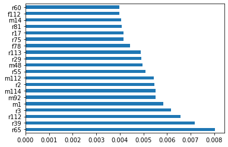

```python
# Could be interesting to see what percentage of monetary/frequency/recency metrics is used in top k features

feat_importances = pd.Series(rf.feature_importances_, index=X_train.columns)
feat_importances.nlargest(20).plot(kind='barh')
```

## Without vector space translation, with original features

```python
### EXPERIMENTAL ###

df_train_grouped = df_train.groupby(['Dlvr_Pnt_No']).mean().fillna(10000).reset_index(drop=False)
df_test_grouped = df_test.groupby(['Dlvr_Pnt_No']).mean().fillna(10000).reset_index(drop=False)

df_embeddings_train_features = df_embeddings_train.merge(df_train_grouped, left_on = 'Dlvr_Pnt_No', right_on = 'Dlvr_Pnt_No', how='left')
df_embeddings_test_features = df_embeddings_test.merge(df_test_grouped, left_on = 'Dlvr_Pnt_No', right_on = 'Dlvr_Pnt_No', how='left')
```

```python
X_train = df_embeddings_train_features.set_index('Dlvr_Pnt_No')
Y_train = df_train_labels.set_index('Dlvr_Pnt_No')

X_test = df_embeddings_test_features.set_index('Dlvr_Pnt_No')
Y_test = df_test_labels.set_index('Dlvr_Pnt_No')
```

```python
from sklearn.ensemble import RandomForestClassifier

rf = RandomForestClassifier(n_jobs=6, verbose=1)

rf.fit(X_train,Y_train)

y_predproba = rf.predict_proba(X_test)
y_true = Y_test
y_pred = rf.predict(X_test)

# I changed this to 1 minus predproba [0] because if during training the brand was never bought, the classifier will only
# give an array with 1 element instead of 2. Hence, indexing on position 1 is impossible.
y_predproba = np.array([[ 1 - y_predproba[l][r][0] for l in range(len(y_predproba))] for r in range(len(y_predproba[0]))])
```

```
[Parallel(n_jobs=6)]: Using backend ThreadingBackend with 6 concurrent workers.
[Parallel(n_jobs=6)]: Done  38 tasks      | elapsed:    2.8s
[Parallel(n_jobs=6)]: Done 100 out of 100 | elapsed:    6.9s finished
[Parallel(n_jobs=6)]: Using backend ThreadingBackend with 6 concurrent workers.
[Parallel(n_jobs=6)]: Done  38 tasks      | elapsed:    0.3s
[Parallel(n_jobs=6)]: Done 100 out of 100 | elapsed:    0.7s finished
[Parallel(n_jobs=6)]: Using backend ThreadingBackend with 6 concurrent workers.
[Parallel(n_jobs=6)]: Done  38 tasks      | elapsed:    0.3s
[Parallel(n_jobs=6)]: Done 100 out of 100 | elapsed:    0.7s finished
```

```python
score = evaluate_classifier(y_true, y_predproba, y_pred, brands, k=k, threshold=threshold)
score['config_name'] = "Random Forest with original features without vector space translation"
scores = scores.append(score, ignore_index=True)
```

```
Mean precision at k=1: 0.73
Mean recall at k=1: 0.98
Hamming loss: 0.10137629027213012
MAPK: 0.9209
Macro F1 score at k=1: 0.1465
Micro F1 score at k=1: 0.5767
Weighted F1 score at k=1: 0.4708
```

# Benchmark: Recommender Systems

## Multi-Label Classification without Network

**Challenge**: Currently the number of available features is too low for multi-class classification. Even with the induced features (recency, frequency, monetary) there are just 4 features.

```python
df_train, df_train_labels, df_test, df_test_labels = get_train_val_test_split(df)
```

```python
df_train_grouped = df_train.groupby(['Dlvr_Pnt_No']).mean().fillna(10000).reset_index(drop=False)
df_test_grouped = df_test.groupby(['Dlvr_Pnt_No']).mean().fillna(10000).reset_index(drop=False)
```

```python
# labels
df_train_labels = pd.get_dummies(df_train_labels[['Dlvr_Pnt_No', 'brand']], columns = ['brand']).groupby('Dlvr_Pnt_No').max()
# Merge with the brands bought
df_train_labels = df_train_grouped[['Dlvr_Pnt_No']].merge(df_train_labels, left_on='Dlvr_Pnt_No', right_on='Dlvr_Pnt_No', how='left')
# fill nans
df_train_labels.fillna(0, inplace=True)
```

```python
# labels
df_test_labels = pd.get_dummies(df_test_labels[['Dlvr_Pnt_No', 'brand']], columns = ['brand']).groupby('Dlvr_Pnt_No').max()
# Merge with the brands bought
df_test_labels = df_test_grouped[['Dlvr_Pnt_No']].merge(df_test_labels, left_on='Dlvr_Pnt_No', right_on='Dlvr_Pnt_No', how='left')
# fill nans
df_test_labels.fillna(0, inplace=True)
```

```python
label_subset = [label for label in df_train_labels.columns if label in df_test_labels.columns]
df_test_labels = df_test_labels[label_subset]
```

```python
X_train = df_train_grouped.set_index('Dlvr_Pnt_No')
Y_train = df_train_labels.set_index('Dlvr_Pnt_No')

X_test = df_test_grouped.set_index('Dlvr_Pnt_No')
Y_test = df_test_labels.set_index('Dlvr_Pnt_No')
```

```python
from sklearn.ensemble import RandomForestClassifier

rf = RandomForestClassifier(n_jobs=4, verbose=1)

rf.fit(X_train,Y_train)

y_predproba = rf.predict_proba(X_test)
y_true = Y_test
y_pred = rf.predict(X_test)

#I changed this to 1 minus predproba [0] because if during training the brand was never bought, the classifier will only
# give an array with 1 element instead of 2. Hence, indexing on position 1 is impossible.
y_predproba = np.array([[ 1 - y_predproba[l][r][0] for l in range(len(y_predproba))] for r in range(len(y_predproba[0]))])
```

```
[Parallel(n_jobs=4)]: Using backend ThreadingBackend with 4 concurrent workers.
[Parallel(n_jobs=4)]: Done  42 tasks      | elapsed:    0.8s
[Parallel(n_jobs=4)]: Done 100 out of 100 | elapsed:    1.7s finished
[Parallel(n_jobs=4)]: Using backend ThreadingBackend with 4 concurrent workers.
[Parallel(n_jobs=4)]: Done  42 tasks      | elapsed:    0.3s
[Parallel(n_jobs=4)]: Done 100 out of 100 | elapsed:    0.6s finished
[Parallel(n_jobs=4)]: Using backend ThreadingBackend with 4 concurrent workers.
[Parallel(n_jobs=4)]: Done  42 tasks      | elapsed:    0.2s
[Parallel(n_jobs=4)]: Done 100 out of 100 | elapsed:    0.6s finished
```

```python
# Get a list of all labels (brands)
brands = list(df_test_labels.columns)[1:]
score = evaluate_classifier(y_true, y_predproba, y_pred, brands, k=k, threshold=threshold)
score['config_name'] = "Benchmark: Multi-label classification without network features"
scores = scores.append(score, ignore_index=True)
```

```
Mean precision at k=1: 0.76
Mean recall at k=1: 0.94
Hamming loss: 0.11510344519415523
MAPK: 0.8463
Macro F1 score at k=1: 0.1843
Micro F1 score at k=1: 0.5587
Weighted F1 score at k=1: 0.5025
```

```python
#Start with a clean slate: split dataset again. Parameter values are set in section 5.2
_, _, df_test_rs, df_test_labels_rs = get_train_val_test_split(df)
```

We will only use the df_test_rs and df_test_labels_rs for the recommender systems. Hence: 1 year of data for training, 6 months for prediction.

## Popular recommendation

There is no training stage, and hence no separate training data, for the popular vote.

```python
# Group By 'Brand' and take the sum of values inside all columns. Next, sort the brands by COST_OF_GOODS in descending order.
# Take the first k brands as recommendations.
popular_brands = df_test_rs.groupby(['brand']).sum().sort_values('COST_OF_GOODS', ascending=False).iloc[:5].index.values
```

```python
## Test data
df_test_rs_pop = pd.get_dummies(df_test_labels_rs[['Dlvr_Pnt_No', 'brand']], columns = ['brand']).groupby('Dlvr_Pnt_No').max()
# Merge with the brands bought
df_test_rs_pop = df[['Dlvr_Pnt_No']].drop_duplicates().merge(df_test_rs_pop, left_on='Dlvr_Pnt_No', right_on='Dlvr_Pnt_No', how='left')
# fill nans
df_test_rs_pop.fillna(0, inplace=True)
```

```python
popular_brands_dict = {brand: (0.5+ (1/(2+list(popular_brands).index(brand.replace('brand_', '')))) if brand.replace('brand_', '') in popular_brands else 0) for brand in df_test_rs_pop.columns[1:]}
```

```python
popular_brands_dict_binary = { brand: (1 if brand in 'brand_' + popular_brands else 0) for brand in df_test_rs_pop.columns[1:]}
```

```python
y_predproba = pd.DataFrame().from_dict({client:popular_brands_dict for client in df_test_rs_pop.Dlvr_Pnt_No}, orient='index').values
y_pred = pd.DataFrame().from_dict({client:popular_brands_dict_binary for client in df_test_rs_pop.Dlvr_Pnt_No}, orient='index').values
y_true = df_test_rs_pop.set_index('Dlvr_Pnt_No')
```

```python
# Get a list of all labels (brands)
brands = list(df_test_rs_pop.columns)
score = evaluate_classifier(y_true, y_predproba, y_pred, brands, k=k, threshold=threshold)
score['config_name'] = "Benchmark: popular vote"
scores = scores.append(score, ignore_index=True)
```

```
Mean precision at k=1: 0.46
Mean recall at k=1: 1.0
Hamming loss: 0.13662796271491923
MAPK: 0.6088
Macro F1 score at k=1: 0.0652
Micro F1 score at k=1: 0.3958
Weighted F1 score at k=1: 0.2676
```

## Explicit feedback

https://surprise.readthedocs.io/en/stable/getting_started.html

```python
## Training data
df_train_rs_exp = pd.get_dummies(df_test_rs[['Dlvr_Pnt_No', 'brand']], columns = ['brand']).groupby('Dlvr_Pnt_No').max()
# Merge with the brands bought
df_train_rs_exp = df[['Dlvr_Pnt_No']].drop_duplicates().merge(df_train_rs_exp, left_on='Dlvr_Pnt_No', right_on='Dlvr_Pnt_No', how='left')
# fill nans
df_train_rs_exp.fillna(0, inplace=True)
```

```python
## Test data
df_test_rs_exp = pd.get_dummies(df_test_labels_rs[['Dlvr_Pnt_No', 'brand']], columns = ['brand']).groupby('Dlvr_Pnt_No').max()
# Merge with the brands bought
df_test_rs_exp = df[['Dlvr_Pnt_No']].drop_duplicates().merge(df_test_rs_exp, left_on='Dlvr_Pnt_No', right_on='Dlvr_Pnt_No', how='left')
# fill nans
df_test_rs_exp.fillna(0, inplace=True)
```

```python
df_train_rs_exp = df_train_rs_exp.set_index('Dlvr_Pnt_No').stack().reset_index(drop=False)
df_test_rs_exp = df_test_rs_exp.set_index('Dlvr_Pnt_No').stack().reset_index(drop=False)
```

```python
df_train_rs_exp.columns = ['Dlvr_Pnt_No', 'brand', 'bought']
df_test_rs_exp.columns = ['Dlvr_Pnt_No', 'brand', 'bought']
```

```python
import pandas as pd

from surprise import SVD
from surprise import Dataset
from surprise import Reader
from surprise.model_selection import cross_validate
from surprise import dataset

# A reader is still needed but only the rating_scale param is requiered.
reader = Reader(rating_scale=(0, 1))

# The columns must correspond to user id, item id and ratings (in that order).
data_train = Dataset.load_from_df(df_train_rs_exp, reader).build_full_trainset()
data_test = Dataset.load_from_df(df_test_rs_exp, reader).build_full_trainset().build_testset()

algo = SVD(verbose=True)
algo.fit(data_train)
predictions = algo.test(data_test)
```

[output not shown]

```python
user_est_true, precisions, recalls = precision_recall_at_k(predictions, k=k, threshold=threshold)
```

```python
##AP, AR

print("Popular recommendation: mean precision at k={}: {}".format(k, (sum(prec for prec in precisions.values()) / len(precisions)).round(2)))
print("Popular recommendation: mean recall at k={}: {}".format(k, (sum(rec for rec in recalls.values()) / len(recalls)).round(2)))


## MAPK
# First map the predictions to each user.
from collections import defaultdict

user_est = defaultdict(list)
actual_values = defaultdict(list)
for uid, brand, true_r, est, _ in predictions:
    user_est[uid].append((brand, est))
    if true_r == 1.0:
        actual_values[uid].append(brand)

predicted = [[b for b,v in sorted(user_est[user], key=lambda x: x[0], reverse=True)] for user in user_est]
actual = [[b for b in actual_values[user]] for user in actual_values]

print("Popular recommendation: MAPK: {}".format(mapk(actual, predicted, k=k)))
```

```
Popular recommendation: mean precision at k=1: 1.0
Popular recommendation: mean recall at k=1: 0.49
Popular recommendation: MAPK: 0.005593288054334798
```

```python
temp_df_y_predproba = pd.DataFrame(columns=y_true.columns)
temp_dict_y_predproba = {}
for i, prediction in tqdm(enumerate(predictions)):
    temp_dict_y_predproba[i] = {'Dlvr_Pnt_No': prediction.uid, prediction.iid: prediction.est}
    #temp_dict['Dlvr_Pnt_Id'] =
    #temp_dict[prediction.iid] = prediction.est

    #temp_df.append(temp_dict, ignore_index=True)

temp_df_y_true = pd.DataFrame(columns=y_true.columns)
temp_dict_y_true = {}
for i, prediction in tqdm(enumerate(predictions)):
    temp_dict_y_true[i] = {'Dlvr_Pnt_No': prediction.uid, prediction.iid: prediction.r_ui}
```

```
365079it [00:00, 931293.49it/s]
365079it [00:00, 1022435.33it/s]
```

```python
df_y_predproba = temp_df_y_predproba.from_dict(temp_dict_y_predproba, orient='index').groupby('Dlvr_Pnt_No').max()
```

```python
df_y_predproba
```

| Dlvr_Pnt_No | brand_arizona | brand_barqs | brand_c+ | brand_canada_dry | brand_cherry_coke | brand_coca_cola | brand_coca_cola_diet | brand_coca_cola_vanilla | brand_core_power | brand_dasani | brand_delaware_punch | brand_dr_pepper | brand_evian | brand_fanta | brand_fresca | brand_full_throttle | brand_fuze_tea | brand_georgia_coffee | brand_ginger_ale | brand_glaceau | brand_gold_peak | brand_honest_tea | brand_illy | brand_mello_yello | brand_monster | brand_mr_pibb | brand_nestea | brand_nos | brand_others | … |
| --- | --- | --- | --- | --- | --- | --- | --- | --- | --- | --- | --- | --- | --- | --- | --- | --- | --- | --- | --- | --- | --- | --- | --- | --- | --- | --- | --- | --- | --- | --- |
| 10824 | 0.000000 | 0.000000 | 0.000000 | 0.000000 | 0.000000 | 0.000000 | 0.000000 | 0.000000 | 0.009876 | 0.000000 | 0.000000 | 0.000000 | 0.000000 | 0.000000 | 0.000000 | 0.000000 | 0.000000 | 0.009876 | 0.000000 | 0.000000 | 0.000000 | 0.000000 | 0.000000 | 0.000000 | 0.000000 | 0.000000 | 0.000000 | 0.000000 | 0.000000 | … |
| 21927 | 0.055276 | 0.040190 | 0.058590 | 0.062445 | 0.060172 | 0.046358 | 0.048636 | 0.048852 | 0.170891 | 0.054524 | 0.053755 | 0.054780 | 0.048396 | 0.052188 | 0.047488 | 0.049883 | 0.055871 | 0.170891 | 0.058885 | 0.053402 | 0.045600 | 0.052457 | 0.053280 | 0.047559 | 0.063353 | 0.049090 | 0.049763 | 0.052479 | 0.052059 | … |
| 27175 | 0.034991 | 0.070654 | 0.028619 | 0.015746 | 0.055564 | 0.072305 | 0.064086 | 0.028987 | 0.158781 | 0.060154 | 0.034449 | 0.066163 | 0.023933 | 0.086334 | 0.026586 | 0.032033 | 0.035715 | 0.158781 | 0.016916 | 0.029076 | 0.036870 | 0.032685 | 0.033782 | 0.040295 | 0.031713 | 0.058106 | 0.044898 | 0.038727 | 0.038224 | … |
| 27578 | 0.000000 | 0.000000 | 0.000000 | 0.000000 | 0.000000 | 0.000000 | 0.000000 | 0.000000 | 0.000000 | 0.000000 | 0.000000 | 0.000000 | 0.000000 | 0.000000 | 0.000000 | 0.000000 | 0.000000 | 0.000000 | 0.000000 | 0.000000 | 0.000000 | 0.000000 | 0.000000 | 0.000000 | 0.000000 | 0.000000 | 0.000000 | 0.000000 | 0.000000 | … |
| 29028 | 0.000000 | 0.000000 | 0.000000 | 0.000000 | 0.000000 | 0.000000 | 0.000000 | 0.000000 | 0.067346 | 0.000000 | 0.000000 | 0.000000 | 0.000000 | 0.000000 | 0.000000 | 0.000000 | 0.000000 | 0.067346 | 0.000000 | 0.000000 | 0.000000 | 0.000000 | 0.000000 | 0.000000 | 0.000000 | 0.000000 | 0.000000 | 0.000000 | 0.000000 | … |
| ... | ... | ... | ... | ... | ... | ... | ... | ... | ... | ... | ... | ... | ... | ... | ... | ... | ... | ... | ... | ... | ... | ... | ... | ... | ... | ... | ... | ... | ... | … |
| 9990506 | 0.000000 | 0.027973 | 0.000000 | 0.000000 | 0.000000 | 0.013259 | 0.018136 | 0.001799 | 0.118198 | 0.003502 | 0.000000 | 0.028624 | 0.000000 | 0.000000 | 0.000000 | 0.000000 | 0.000000 | 0.118198 | 0.000000 | 0.000364 | 0.007366 | 0.000000 | 0.000000 | 0.000000 | 0.000000 | 0.000000 | 0.000000 | 0.000000 | 0.000000 | … |
| 9990773 | 0.026277 | 0.009689 | 0.023953 | 0.012372 | 0.023255 | 0.009842 | 0.013281 | 0.022591 | 0.138572 | 0.001557 | 0.026811 | 0.009508 | 0.025935 | 0.007100 | 0.026260 | 0.025502 | 0.018199 | 0.138572 | 0.014090 | 0.015552 | 0.023912 | 0.028082 | 0.028299 | 0.014539 | 0.027819 | 0.027188 | 0.000000 | 0.023076 | 0.027952 | … |
| 9993246 | 0.020538 | 0.009800 | 0.019499 | 0.011385 | 0.026536 | 0.050760 | 0.048216 | 0.020513 | 0.140917 | 0.029338 | 0.021203 | 0.031290 | 0.016603 | 0.019329 | 0.019233 | 0.027844 | 0.014519 | 0.140917 | 0.018001 | 0.008559 | 0.015020 | 0.021556 | 0.021994 | 0.024478 | 0.022161 | 0.021290 | 0.039747 | 0.022440 | 0.019587 | … |
| 9993314 | 0.000000 | 0.000000 | 0.000000 | 0.000000 | 0.000000 | 0.000000 | 0.000000 | 0.000000 | 0.000075 | 0.000000 | 0.000000 | 0.000000 | 0.000000 | 0.000000 | 0.000000 | 0.000000 | 0.000000 | 0.000075 | 0.000000 | 0.000000 | 0.000000 | 0.000000 | 0.000000 | 0.000000 | 0.000000 | 0.000000 | 0.000000 | 0.000000 | 0.000000 | … |
| 9998161 | 0.046782 | 0.038046 | 0.039396 | 0.037568 | 0.036396 | 0.035846 | 0.029137 | 0.043645 | 0.159229 | 0.041053 | 0.045153 | 0.034119 | 0.041733 | 0.046472 | 0.038800 | 0.041567 | 0.042311 | 0.159229 | 0.036270 | 0.041523 | 0.037357 | 0.045680 | 0.045568 | 0.043994 | 0.045995 | 0.047695 | 0.035924 | 0.033668 | 0.045320 | … |

9867 rows × 37 columns

```python
df_y_pred = df_y_predproba.copy()
df_y_pred[df_y_predproba >= threshold] = 1
df_y_pred[~(df_y_predproba >= threshold)] = 0
```

```python
df_y_true = temp_df_y_true.from_dict(temp_dict_y_true, orient='index').groupby('Dlvr_Pnt_No').max()
```

```python
y_pred = df_y_pred.values
y_predproba = df_y_predproba.values
y_true = df_y_true
```

```python
brands = list(y_true.columns)
score = evaluate_classifier(y_true, y_predproba, y_pred, brands, k=k, threshold=threshold)
score['config_name'] = "Benchmark: explicit feedback"
scores = scores.append(score, ignore_index=True)
```

```
Mean precision at k=1: 1.0
Mean recall at k=1: 0.96
Hamming loss: 0.09115287376156941
MAPK: 0.4927
Macro F1 score at k=1: 0.0097
Micro F1 score at k=1: 0.0038
Weighted F1 score at k=1: 0.0037
```

**Error:** The MAPK scores do not match so far... have to investigate this further.

## Implicit Feedback

checked is ok! Here I still need to check what data is used! We have agreed to use only df_test data (1 year train, 6 months test)! (I already did this change in the explicit feedback section)

```python
# The first 52 weeks of what we consider the test period can be used for training in the implicit case.
df_train_rs_imp = df_test_rs
df_test_rs_imp = df_test_labels_rs
```

```python
# For every Dlvr_Pnt_No and brand combination: how frequent was this purchase.
grouped_purchased = df_train_rs_imp.groupby(['Dlvr_Pnt_No','brand'])['frequency'].sum().reset_index()
```

```python
from scipy import sparse

customers = list(np.sort(grouped_purchased.Dlvr_Pnt_No.unique())) # Get our unique customers
brands = list(grouped_purchased.brand.unique()) # Get our unique products that were purchased
frequency = list(grouped_purchased.frequency) # All of our purchases

a = grouped_purchased.Dlvr_Pnt_No.astype('category')
b = dict(enumerate(a.cat.categories))

c = grouped_purchased.brand.astype('category')
d = dict(enumerate(c.cat.categories))

rows = grouped_purchased.Dlvr_Pnt_No.astype('category').cat.codes
# Get the associated row indices
cols = grouped_purchased.brand.astype('category').cat.codes
# Get the associated column indices
user_items = sparse.csr_matrix((frequency, (rows, cols)), shape=(len(customers), len(brands)))
#item_users = sparse.csr_matrix((frequency, (cols, rows)), shape=( len(products), len(customers)))
item_users = user_items.T.tocsr()
```

```python
from implicit.als import AlternatingLeastSquares
# initialize a model
model = AlternatingLeastSquares(factors=50)

# train the model on a sparse matrix of item/user/confidence weights
model.fit(item_users)

# recommend items for a user
#user_items = item_user_data.T.tocsr()
recommendations = model.recommend_all(user_items, N=10, filter_already_liked_items=False)

# find related items
#related = model.similar_items(250)
```

```
WARNING - 12:18:40: Intel MKL BLAS detected. Its highly recommend to set the environment variable 'export MKL_NUM_THREADS=1' to disable its internal multithreading
```

```python
# We only want recommendations for customers in the test-set
customer_cat_code = list(grouped_purchased.Dlvr_Pnt_No.astype('category').cat.categories)
not_found= 0
cust_ids = []
customers_test = list(set(df_test_rs_imp.Dlvr_Pnt_No))

for cust in customers_test:
    try:
        cust_ids.append(customer_cat_code.index(cust))
    except:
        not_found += 1
        pass
print(not_found)

recommendations_test = recommendations[cust_ids]
```

```
299
```

```python
print("There are {} unique customers in the test set. \n \
Not every customer has bought something in the past year. \n \
Hence, the RS can only predict for customers that were already present in the training data. \n \
In total {} customers were present.".format(len(customers_test), len(cust_ids)))
```

```
There are 5006 unique customers in the test set.
 Not every customer has bought something in the past year.
 Hence, the RS can only predict for customers that were already present in the training data.
 In total 4707 customers were present.
```

```python
brands_bought = df_test_rs_imp.groupby(['Dlvr_Pnt_No']).brand.apply(list)
actual_test = [set(brands_bought[cust]) for cust in customers_test]
```

```python
def translate(i):
    try:
        return d[i]
    except:
        return "cust_not_found"
```

```python
def find_customer(i):
    """this function retrieves the original Dlvr_Pnt_Id associated with the sparse matrix integer index"""
    try:
        return b[i]
    except:
        return "cust_not_found"
```

```python
predicted_test = [list(map(translate, suba)) for suba in recommendations_test]
```

```python
mapk(actual_test, predicted_test, k=k)
```

```
0.532398555343106
```

```python
# Calculating the sparsity of the matrix
matrix_size = user_items.shape[0]*user_items.shape[1] # Number of possible interactions in the matrix
num_purchases = len(user_items.nonzero()[0]) # Number of items interacted with
sparsity = 100*(1 - (num_purchases/matrix_size))
sparsity
```

```
80.1089563132103
```

```python
test_rec = dict()
for cust in cust_ids:
    test_rec[cust] = model.rank_items(userid = cust, user_items=user_items, selected_items=recommendations[cust])
```

```python
## Test data
y_true = pd.get_dummies(df_test_rs_imp[['Dlvr_Pnt_No', 'brand']], columns = ['brand']).groupby('Dlvr_Pnt_No').max()
# Merge with all clients in the test set
y_true = df_test_rs_imp[['Dlvr_Pnt_No']].drop_duplicates().merge(y_true, left_on='Dlvr_Pnt_No', right_on='Dlvr_Pnt_No', how='left')
# fill nans
y_true.fillna(0, inplace=True)

y_true.set_index('Dlvr_Pnt_No', inplace=True)
```

**Ok, Houston we have a problem...** So far the test set contained all Dlvr_Pnt_No (clients) regardless of whether they buy something. But because not all products have been mapped to brands, some customers in the test set appear to have bought nothing. For a recommender system this is a tricky situation as it will most certainly recommend something... We need to fix this to get thrustworthy results

```
So the current scores of the implicit feedback RS are actually not thrustworthy as there is leakage of test set information... We only ask it to predict customers of whom we know they have bought something.
```

```python
# Creating the y_pred table
y_pred = pd.DataFrame(columns=y_true.columns)
dt = dict()
for cust in cust_ids:
    recs = recommendations[cust]
    dt[cust] = {'brand_'+ translate(rec):1 for rec in recs}

y_pred = y_pred.from_dict(dt, orient='index', columns=y_true.columns)

y_pred.sort_index(inplace=True)
y_pred.index.rename('Dlvr_Pnt_No', inplace=True)
y_pred.reset_index(drop=False, inplace=True)
y_pred["Dlvr_Pnt_No_orig"] = y_pred.Dlvr_Pnt_No.apply(find_customer)
y_pred.drop('Dlvr_Pnt_No', axis=1, inplace=True)
#y_pred.set_index("Dlvr_Pnt_No_orig", inplace=True)
#y_pred.sort_index(inplace=True)

# Merge with the brands bought
y_pred = df_test_rs_imp[['Dlvr_Pnt_No']].drop_duplicates().merge(y_pred, left_on='Dlvr_Pnt_No', right_on='Dlvr_Pnt_No_orig',  how='left')
# fill nans
y_pred.fillna(0, inplace=True)

y_pred.set_index('Dlvr_Pnt_No', inplace=True)
y_pred.drop('Dlvr_Pnt_No_orig', inplace=True, axis=1)

y_pred = y_pred.values
```

```python
# Creating the y_predproba table
y_predproba = pd.DataFrame(columns=y_true.columns)

test_rec = dict()
for cust in cust_ids:
    test_rec[cust] = {'brand_' + translate(item): score for item, score in model.rank_items(userid = cust, user_items=user_items, selected_items=recommendations[cust])}

y_predproba = y_predproba.from_dict(test_rec, orient='index', columns=y_true.columns)
y_predproba.index.rename('Dlvr_Pnt_No', inplace=True)
y_predproba.reset_index(drop=False, inplace=True)
y_predproba["Dlvr_Pnt_No_orig"] = y_predproba.Dlvr_Pnt_No.apply(find_customer)
y_predproba.drop('Dlvr_Pnt_No', axis=1, inplace=True)
#y_predproba.set_index("Dlvr_Pnt_No_orig", inplace=True)
#y_predproba.sort_index(inplace=True)

# Merge with the brands bought
y_predproba = df_test_rs_imp[['Dlvr_Pnt_No']].drop_duplicates().merge(y_predproba, left_on='Dlvr_Pnt_No', right_on='Dlvr_Pnt_No_orig',  how='left')
# fill nans
y_predproba.fillna(0, inplace=True)

y_predproba.set_index('Dlvr_Pnt_No', inplace=True)
y_predproba.drop('Dlvr_Pnt_No_orig', inplace=True, axis=1)

y_predproba = y_predproba.values
```

```python
brands = list(y_true.columns)
score = evaluate_classifier(y_true, y_predproba, y_pred, brands, k=k, threshold=threshold)
score['config_name'] = "Benchmark: implicit feedback"
scores = scores.append(score, ignore_index=True)
```

```
Mean precision at k=1: 0.69
Mean recall at k=1: 0.94
Hamming loss: 0.13009253760352443
MAPK: 0.6346
Macro F1 score at k=1: 0.4693
Micro F1 score at k=1: 0.6996
Weighted F1 score at k=1: 0.7429
```

> *NOTE:* In order to calculate rank-based measures we should check whether the order in which recommendations are currently returned, matches the ranking. Use rank_items() method on the items in the recommendation

# Postprocessing

```python
# Writing scores to file
scores.to_csv('_'.join(['scores', 'k', str(k), 'threshold', str(threshold)]) + '.csv')
```

```python
scores
```

|  | threshold | k | ap | ar | hl | ma | f1_macro | f1_micro | f1_average | config_name |
| --- | --- | --- | --- | --- | --- | --- | --- | --- | --- | --- |
| 0 | 0.5 | 1 | 0.735064 | 0.982796 | 0.101667 | 0.920551 | 0.143142 | 0.574395 | 0.466785 | Random Forest without vector space translation |
| 1 | 0.5 | 1 | 1.000000 | 0.350641 | 0.140645 | 0.263841 | 0.000000 | 0.000000 | 0.000000 | Random Forest with vector space translation |
| 2 | 0.5 | 1 | 0.730685 | 0.982327 | 0.101376 | 0.920863 | 0.146506 | 0.576743 | 0.470843 | Random Forest with original features without v... |
| 3 | 0.5 | 1 | 0.758054 | 0.941977 | 0.115103 | 0.846262 | 0.184269 | 0.558687 | 0.502536 | Benchmark: Multi-label classification without ... |
| 4 | 0.5 | 1 | 0.464478 | 1.000000 | 0.136628 | 0.608797 | 0.065159 | 0.395833 | 0.267629 | Benchmark: popular vote |
| 5 | 0.5 | 1 | 0.995845 | 0.963211 | 0.091153 | 0.492652 | 0.009667 | 0.003832 | 0.003744 | Benchmark: explicit feedback |
| 6 | 0.5 | 1 | 0.694367 | 0.940272 | 0.130093 | 0.634638 | 0.469287 | 0.699641 | 0.742880 | Benchmark: implicit feedback |